# Election Analysis

## by Idongesit Inyang

# Investigation Overview

### Dataset Overview

I had access to four datasets consisting of candidates of 2015 and 2019 elections and the state and how each state voted.

|  | State | Buhari | Jonathan | Ayeni | Galadima | Eke | Salau | Ahmad | Chinedu | Onovo | Kelani | Okorie | Sonaiya | Okoye | Owuru | Region |
| --- | --- | --- | --- | --- | --- | --- | --- | --- | --- | --- | --- | --- | --- | --- | --- | --- |
| 1 | Kano | 1903999 | 215779 | 2770 | 778 | 1552 | 708 | 657 | 485 | 697 | 426 | 156 | 288 | 234 | 292 | North_West |
| 2 | Katsina | 1345441 | 98937 | 1671 | 402 | 976 | 283 | 498 | 254 | 330 | 183 | 72 | 215 | 117 | 47 | North_West |
| 3 | Kaduna | 1127760 | 484085 | 1611 | 424 | 824 | 273 | 546 | 549 | 754 | 218 | 78 | 176 | 79 | 105 | North_West |
| 4 | Bauchi | 931598 | 86085 | 964 | 232 | 391 | 173 | 189 | 128 | 207 | 131 | 37 | 128 | 29 | 46 | North_East |
| 5 | Jigawa | 885988 | 142904 | 2527 | 540 | 1553 | 587 | 375 | 853 | 548 | 394 | 197 | 423 | 338 | 337 | North_West |
| 6 | Lagos | 792460 | 632327 | 2177 | 3038 | 1125 | 4453 | 2072 | 1041 | 1430 | 1795 | 244 | 1000 | 269 | 255 | South_West |
| 7 | Sokoto | 671926 | 152199 | 3482 | 535 | 1894 | 714 | 762 | 605 | 686 | 249 | 180 | 475 | 269 | 283 | North_West |
| 8 | Niger | 657678 | 149222 | 2006 | 441 | 1264 | 403 | 614 | 449 | 550 | 307 | 118 | 305 | 116 | 198 | North_Central |
| 9 | Zamfara | 612202 | 144833 | 1310 | 238 | 655 | 290 | 294 | 374 | 404 | 125 | 68 | 122 | 93 | 14 | North_West |
| 10 | Kebbi | 567883 | 100972 | 2685 | 361 | 1794 | 450 | 472 | 547 | 519 | 214 | 238 | 448 | 207 | 213 | North_West |
| 11 | Oyo | 528620 | 303376 | 4468 | 8979 | 6674 | 6282 | 5000 | 2842 | 1895 | 6331 | 3665 | 1312 | 1069 | 839 | South_West |
| 12 | Borno | 473543 | 25640 | 878 | 243 | 310 | 392 | 201 | 143 | 107 | 145 | 41 | 158 | 31 | 88 | North_East |
| 13 | Yobe | 446265 | 25526 | 632 | 164 | 329 | 213 | 112 | 101 | 120 | 101 | 32 | 104 | 30 | 67 | North_East |
| 14 | Plateau | 429140 | 549615 | 618 | 391 | 237 | 279 | 406 | 554 | 693 | 178 | 29 | 138 | 54 | 56 | North_Central |
| 15 | Osun | 383603 | 249929 | 1306 | 1731 | 1029 | 1667 | 937 | 599 | 767 | 377 | 159 | 255 | 124 | 132 | South_West |
| 16 | Adamawa | 374701 | 251664 | 1549 | 1166 | 819 | 595 | 1012 | 1163 | 1212 | 495 | 334 | 752 | 289 | 267 | North_East |
| 17 | Benue | 373961 | 303737 | 945 | 1464 | 567 | 254 | 539 | 439 | 683 | 315 | 74 | 105 | 66 | 115 | North_Central |
| 18 | Gombe | 361245 | 96873 | 773 | 192 | 407 | 169 | 247 | 157 | 227 | 104 | 37 | 97 | 25 | 46 | North_East |
| 19 | Ogun | 308290 | 207950 | 1930 | 3072 | 978 | 1927 | 1364 | 4339 | 815 | 584 | 597 | 432 | 562 | 332 | South_West |
| 20 | Kwara | 302146 | 132602 | 1165 | 817 | 910 | 520 | 438 | 325 | 394 | 248 | 102 | 214 | 81 | 118 | North_Central |
| 21 | Ondo | 299889 | 251368 | 1139 | 2406 | 1012 | 1237 | 1227 | 734 | 846 | 386 | 221 | 223 | 184 | 184 | South_West |
| 22 | Kogi | 264851 | 149987 | 1001 | 1089 | 967 | 427 | 761 | 476 | 399 | 700 | 156 | 190 | 180 | 144 | North_Central |
| 23 | Taraba | 261326 | 310800 | 1306 | 811 | 1033 | 586 | 320 | 680 | 876 | 962 | 439 | 153 | 224 | 161 | North_East |
| 24 | Nassarawa | 236838 | 273460 | 310 | 95 | 131 | 74 | 105 | 164 | 222 | 40 | 33 | 48 | 23 | 4 | North_Central |
| 25 | Edo | 208469 | 286869 | 709 | 1284 | 325 | 450 | 512 | 729 | 516 | 159 | 72 | 175 | 160 | 22 | South_South |
| 26 | FCT | 146399 | 157195 | 674 | 342 | 347 | 240 | 288 | 269 | 473 | 139 | 96 | 165 | 95 | 83 | North_Central |
| 27 | Imo | 133253 | 559185 | 2236 | 956 | 733 | 757 | 1617 | 414 | 784 | 533 | 1917 | 158 | 264 | 157 | South_East |
| 28 | Ekiti | 120331 | 176466 | 482 | 538 | 330 | 854 | 424 | 388 | 377 | 94 | 145 | 108 | 60 | 94 | South_West |
| 29 | Rivers | 69238 | 1487075 | 513 | 525 | 577 | 1104 | 1031 | 492 | 565 | 1066 | 156 | 2274 | 303 | 542 | South_South |
| 30 | Akwa Ibom | 58411 | 953304 | 384 | 443 | 412 | 474 | 608 | 327 | 381 | 1600 | 144 | 160 | 224 | 192 | South_South |
| 31 | Delta | 48910 | 1211405 | 478 | 916 | 813 | 735 | 888 | 393 | 670 | 1473 | 261 | 311 | 354 | 166 | South_South |
| 32 | Cross River | 28368 | 414863 | 532 | 514 | 381 | 709 | 749 | 864 | 930 | 279 | 1487 | 312 | 289 | 237 | South_South |
| 33 | Ebonyi | 19518 | 323653 | 2452 | 1214 | 2345 | 1133 | 2704 | 1168 | 1890 | 426 | 4859 | 913 | 624 | 989 | South_East |
| 34 | Anambra | 17926 | 660762 | 2303 | 1259 | 1279 | 475 | 534 | 537 | 887 | 547 | 1121 | 311 | 286 | 357 | South_East |
| 35 | Enugu | 14157 | 553003 | 715 | 479 | 237 | 269 | 478 | 407 | 761 | 441 | 290 | 203 | 1623 | 110 | South_East |
| 36 | Abia | 13394 | 368303 | 2766 | 2194 | 1046 | 448 | 569 | 424 | 745 | 315 | 330 | 173 | 213 | 125 | South_East |
| 37 | Bayelsa | 5194 | 361209 | 70 | 38 | 44 | 69 | 116 | 62 | 95 | 45 | 35 | 52 | 20 | 18 | South_South |

|  | State | Buhari | Atiku | Nicolas | Sowore | Moghalu | Durotoye | Duke | Mailafia | Region |
| --- | --- | --- | --- | --- | --- | --- | --- | --- | --- | --- |
| 0 | Abia | 85058 | 219698 | 1489 | 212 | 88 | 720 | 472 | 336 | South_East |
| 1 | Adamawa | 378078 | 410266 | 3670 | 282 | 109 | 162 | 978 | 3989 | North_East |
| 2 | Akwa Ibom | 175429 | 395832 | 1902 | 222 | 118 | 95 | 92 | 230 | South_South |
| 3 | Anambra | 33298 | 524738 | 4374 | 124 | 4091 | 45 | 932 | 227 | South_East |
| 4 | Bauchi | 798428 | 209313 | 2104 | 183 | 112 | 46 | 516 | 296 | North_East |
| 5 | Bayelsa | 118821 | 197933 | 1584 | 126 | 50 | 37 | 124 | 1078 | South_South |
| 6 | Benue | 347668 | 356817 | 2793 | 309 | 557 | 201 | 4927 | 554 | North_Central |
| 7 | Borno | 836496 | 71788 | 0 | 269 | 78 | 29 | 322 | 301 | North_East |
| 8 | Cross River | 117302 | 295737 | 0 | 242 | 217 | 88 | 1395 | 326 | South_South |
| 9 | Delta | 221292 | 594068 | 0 | 1626 | 497 | 320 | 1745 | 1075 | South_South |
| 10 | Ebonyi | 90726 | 258573 | 0 | 205 | 192 | 683 | 452 | 213 | South_East |
| 11 | Edo | 267842 | 275691 | 0 | 3106 | 531 | 273 | 184 | 850 | South_South |
| 12 | Ekiti | 219231 | 154032 | 0 | 400 | 68 | 88 | 48 | 406 | South_West |
| 13 | Enugu | 54423 | 355553 | 0 | 219 | 1379 | 141 | 130 | 348 | South_East |
| 14 | FCT | 152224 | 259997 | 0 | 583 | 1083 | 652 | 410 | 246 | North_Central |
| 15 | Gombe | 402961 | 138484 | 0 | 165 | 39 | 78 | 248 | 248 | North_East |
| 16 | Imo | 140463 | 334923 | 0 | 467 | 676 | 119 | 772 | 541 | South_East |
| 17 | Jigawa | 794738 | 289895 | 0 | 226 | 67 | 66 | 5011 | 261 | North_West |
| 18 | Kaduna | 993445 | 649612 | 0 | 243 | 196 | 261 | 1737 | 558 | North_West |
| 19 | Kano | 1464768 | 391593 | 0 | 416 | 200 | 114 | 635 | 591 | North_West |
| 20 | Katsina | 1232133 | 308056 | 0 | 186 | 61 | 82 | 150 | 237 | North_West |
| 21 | Kebbi | 581552 | 154282 | 0 | 276 | 53 | 99 | 2376 | 285 | North_West |
| 22 | Kogi | 285894 | 218207 | 0 | 250 | 87 | 89 | 2226 | 4369 | North_Central |
| 23 | Kwara | 308984 | 138184 | 0 | 401 | 140 | 422 | 212 | 456 | North_Central |
| 24 | Lagos | 580825 | 448015 | 0 | 8910 | 5733 | 6946 | 770 | 2915 | South_West |
| 25 | Nassarawa | 289903 | 283847 | 0 | 75 | 44 | 45 | 359 | 339 | North_Central |
| 26 | Niger | 612371 | 218052 | 0 | 324 | 113 | 145 | 239 | 588 | North_Central |
| 27 | Ogun | 281762 | 194655 | 0 | 3196 | 553 | 1509 | 1374 | 25283 | South_West |
| 28 | Ondo | 241769 | 275901 | 0 | 4414 | 1224 | 311 | 1618 | 6296 | South_West |
| 29 | Osun | 347634 | 337377 | 0 | 1022 | 189 | 268 | 259 | 1525 | South_West |
| 30 | Oyo | 365229 | 366690 | 0 | 4014 | 1608 | 1896 | 766 | 40830 | South_West |
| 31 | Plateau | 468555 | 548665 | 0 | 268 | 442 | 796 | 599 | 590 | North_Central |
| 32 | Rivers | 150710 | 473971 | 0 | 372 | 415 | 365 | 1244 | 597 | South_South |
| 33 | Sokoto | 490333 | 361604 | 0 | 181 | 184 | 84 | 301 | 331 | North_West |
| 34 | Taraba | 324906 | 374743 | 0 | 116 | 80 | 35 | 862 | 211 | North_East |
| 35 | Yobe | 497914 | 50763 | 0 | 137 | 36 | 37 | 180 | 162 | North_East |
| 36 | Zamfara | 438682 | 125423 | 0 | 186 | 44 | 24 | 81 | 186 | North_West |

# What is the percentage of Male to women in the 2019 election?

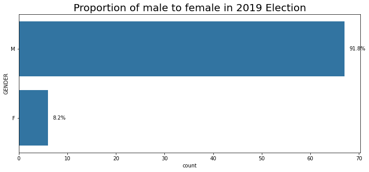

There are 67 males(92%) and 6 female(8%)

# How many votes did each candidate have in 2015?

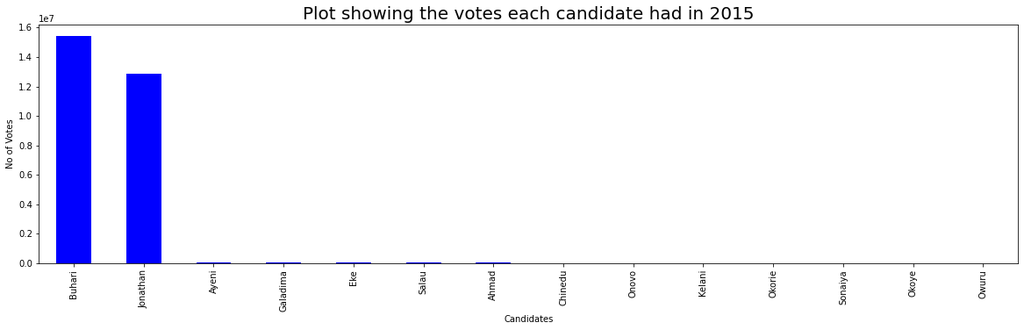

The visualization shows that it was a two candidate race in 2015 as Buhari and Jonathan had the highest votes.

# How many votes did each candidate have in 2019?

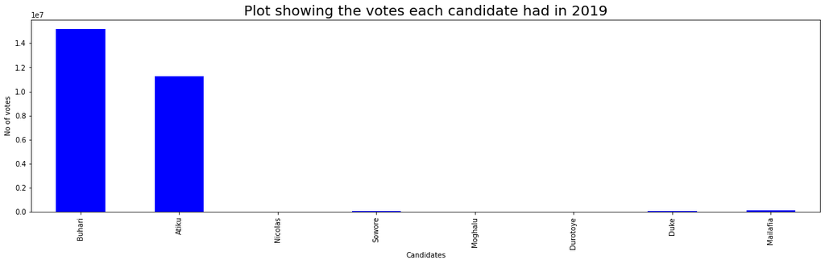

# Which region did the top two candidates have the most votes in the 2015?

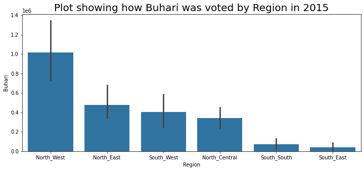

Buhari got his highest number of votes from the North West region(7,115,199), followed by North East(2,848,678), South West (2,433,193)and North Central(2,411,013).

#### Jonathan

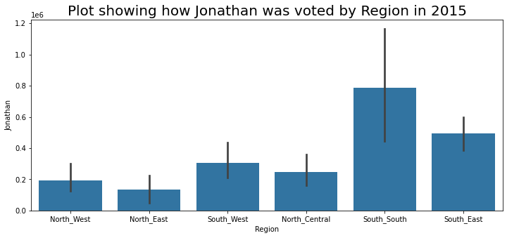

Jonathan got his highest votes from the South South region(4,714,725), followed by South East(2,464,906), and South West(1,821,416)

# Which region did the top two candidates have the most votes in the 2019

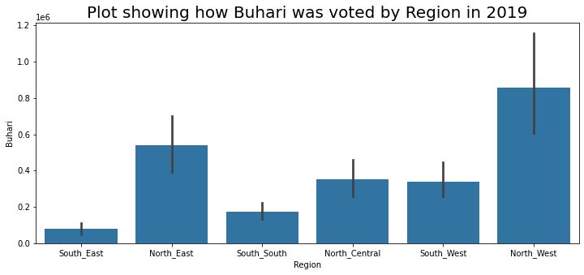

In 2019 election, Buhari of APC had the highest votes from North West, North East, North Central and South West.

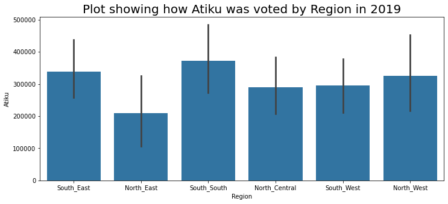

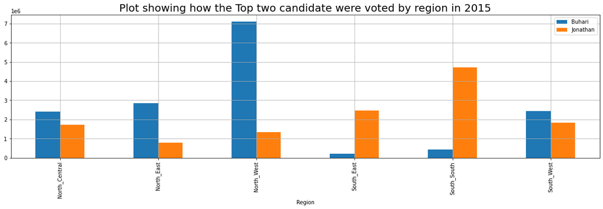

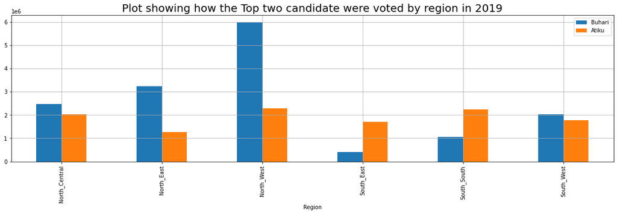

# Conclusion

1) Buhari(APC) had more votes in the Northern region of Nigeria and in the south westin both 2015 and 2019 election

2) Atiku (PDP) had more votes in South south and South East

3) This shows how strong APC party have held down the Northen and South Western region of Nigeria.

[output not shown]